# Lab 4: Childcare Costs in California

Author

Briana Lonappan

## The Data

In this lab we’re going look at the median weekly cost of childcare in California. A detailed description of the data can be found [here](https://github.com/rfordatascience/tidytuesday/blob/master/data/2023/2023-05-09/readme.md).

The data come to us from [TidyTuesday](https://github.com/rfordatascience/tidytuesday).

**0. Load the appropriate libraries and the data.**

```r
library(tidyverse)
library(readxl)
```

```r
library(tidyverse)
library(readxl)
#| label: load-data

childcare_costs <- read_csv('https://raw.githubusercontent.com/rfordatascience/tidytuesday/master/data/2023/2023-05-09/childcare_costs.csv')
counties <- read_csv('https://raw.githubusercontent.com/rfordatascience/tidytuesday/master/data/2023/2023-05-09/counties.csv')
```

**1. Briefly describe the dataset (~ 4 sentences). What information does it contain?**

## California Childcare Costs

Let’s start by focusing only on California.

**2. Create a `ca_childcare` dataset of childcare costs in California, containing (1) county information and (2) all information from the `childcare_costs` dataset.** *Hint: There are 58 counties in CA and 11 years in the dataset. Therefore, your new dataset should have 53 x 11 = 638 observations.*

```r
library(tidyverse)
library(readxl)
#| label: ca-childcare-costs

ca_counties <- counties %>%
  filter(state_name == "California")

ca_childcare <- childcare_costs %>%
  filter(county_fips_code %in% ca_counties$county_fips_code) %>%
  inner_join(ca_counties, by = "county_fips_code")

nrow(ca_childcare)
```

```
[1] 638
```

```r
length(unique(ca_childcare$county_fips_code))
```

```
[1] 58
```

```r
length(unique(ca_childcare$study_year))
```

```
[1] 11
```

```r
head(ca_childcare)
```

```
# A tibble: 6 × 64
  county_fips_code study_year unr_16 funr_16 munr_16 unr_20to64 funr_20to64
             <dbl>      <dbl>  <dbl>   <dbl>   <dbl>      <dbl>       <dbl>
1             6001       2008   6.6     6.57    6.63        6.1         6.1
2             6001       2009   7.71    7.53    7.86        7.2         7.1
3             6001       2010   8.5     8.24    8.73        7.9         7.7
4             6001       2011   9.21    8.87    9.51        8.7         8.4
5             6001       2012   9.91    9.68   10.1         9.3         9.2
6             6001       2013  10.3    10.2    10.5         9.7         9.6
# ℹ 57 more variables: munr_20to64 <dbl>, flfpr_20to64 <dbl>,
#   flfpr_20to64_under6 <dbl>, flfpr_20to64_6to17 <dbl>,
#   flfpr_20to64_under6_6to17 <dbl>, mlfpr_20to64 <dbl>, pr_f <dbl>,
#   pr_p <dbl>, mhi_2018 <dbl>, me_2018 <dbl>, fme_2018 <dbl>, mme_2018 <dbl>,
#   total_pop <dbl>, one_race <dbl>, one_race_w <dbl>, one_race_b <dbl>,
#   one_race_i <dbl>, one_race_a <dbl>, one_race_h <dbl>, one_race_other <dbl>,
#   two_races <dbl>, hispanic <dbl>, households <dbl>, …
```

**3. Using a function from the `forcats` package, complete the code below to create a new variable where each county is categorized into one of the [10 Census regions](https://census.ca.gov/regions/) in California. Use the Region description (from the plot), not the Region number.**  
*Hint: This is probably a good place to use ChatGPT to reduce on tedious work. But you do need to know how to prompt ChatGPT to make it useful!*

```r
library(forcats)
library(tidyverse)
library(stringr)
#| label: recoding-county-to-census-regions

county_region_map <- c(
  "Butte" = "Superior California",
  "Colusa" = "Superior California",
  "El Dorado" = "Superior California",
  "Glenn" = "Superior California",
  "Lassen" = "Superior California",
  "Modoc" = "Superior California",
  "Nevada" = "Superior California",
  "Placer" = "Superior California",
  "Plumas" = "Superior California",
  "Sacramento" = "Superior California",
  "Shasta" = "Superior California",
  "Sierra" = "Superior California",
  "Siskiyou" = "Superior California",
  "Sutter" = "Superior California",
  "Tehama" = "Superior California",
  "Yolo" = "Superior California",
  "Yuba" = "Superior California",
  "Del Norte" = "North Coast",
  "Humboldt" = "North Coast",
  "Lake" = "North Coast",
  "Mendocino" = "North Coast",
  "Napa" = "North Coast",
  "Sonoma" = "North Coast",
  "Trinity" = "North Coast",
  "Alameda" = "San Francisco Bay Area",
  "Contra Costa" = "San Francisco Bay Area",
  "Marin" = "San Francisco Bay Area",
  "San Francisco" = "San Francisco Bay Area",
  "San Mateo" = "San Francisco Bay Area",
  "Santa Clara" = "San Francisco Bay Area",
  "Solano" = "San Francisco Bay Area",
  "Alpine" = "Northern San Joaquin Valley",
  "Amador" = "Northern San Joaquin Valley",
  "Calaveras" = "Northern San Joaquin Valley",
  "Madera" = "Northern San Joaquin Valley",
  "Mariposa" = "Northern San Joaquin Valley",
  "Merced" = "Northern San Joaquin Valley",
  "Mono" = "Northern San Joaquin Valley",
  "San Joaquin" = "Northern San Joaquin Valley",
  "Stanislaus" = "Northern San Joaquin Valley",
  "Tuolumne" = "Northern San Joaquin Valley",
  "Monterey" = "Central Coast",
  "San Benito" = "Central Coast",
  "San Luis Obispo" = "Central Coast",
  "Santa Barbara" = "Central Coast",
  "Santa Cruz" = "Central Coast",
  "Ventura" = "Central Coast",
  "Fresno" = "Southern San Joaquin Valley",
  "Inyo" = "Southern San Joaquin Valley",
  "Kern" = "Southern San Joaquin Valley",
  "Kings" = "Southern San Joaquin Valley",
  "Tulare" = "Southern San Joaquin Valley",
  "Riverside" = "Inland Empire",
  "San Bernardino" = "Inland Empire",
  "Los Angeles" = "Los Angeles County",
  "Orange" = "Orange County",
  "Imperial" = "San Diego - Imperial",
  "San Diego" = "San Diego - Imperial"
)

ca_childcare <- ca_childcare %>%
  mutate(
    county_name = str_remove(county_name, " County"),
    census_region = county_region_map[county_name]
  )
```

**4. Let’s consider the median household income of each region, and how that income has changed over time. Create a table with ten rows, one for each region, and two columns, one for 2008 and one for 2018. The cells should contain the `median` of the median household income (expressed in 2018 dollars) of the `region` and the `study_year`. Arrange the rows by 2018 values.**

```r
library(dplyr)
library(tidyr)
median_income_table <- ca_childcare %>%
  filter(study_year %in% c(2008, 2018)) %>%
  group_by(census_region, study_year) %>%
  summarize(median_income = median(mhi_2018, na.rm = TRUE)) %>%
  pivot_wider(names_from = study_year, values_from = median_income, names_prefix = "Year_") %>%
  arrange(desc(Year_2018))
median_income_table
```

```
# A tibble: 10 × 3
# Groups:   census_region [10]
   census_region               Year_2008 Year_2018
   <chr>                           <dbl>     <dbl>
 1 San Francisco Bay Area         90412.   104552
 2 Orange County                  86452.    85398
 3 Central Coast                  72979     74849
 4 Los Angeles County             63471.    64251
 5 Inland Empire                  65977.    62056
 6 San Diego - Imperial           58201.    60344.
 7 Northern San Joaquin Valley    59108.    57769
 8 Superior California            57831.    53270
 9 Southern San Joaquin Valley    52676.    52479
10 North Coast                    47862.    45528
```

**5. Which California `region` had the lowest `median` full-time median weekly price for center-based childcare for infants in 2018? Does this `region` correspond to the `region` with the lowest `median` income in 2018 that you found in Q4?**  
*Hint: The code should give me the EXACT answer. This means having the code output the exact row(s) and variable(s) necessary for providing the solution.*

**The lowest median weekly price is for infants in 2018 is $215.21 in Superior California. The lowest median income in 2018 is $45,528 in North Coast.**

```r
library(dplyr)
#| label: lowest-median-weekly-price-2018

lowest_median_price_region <- ca_childcare %>%
  filter(study_year == 2018) %>%
  group_by(census_region) %>%
  summarise(median_weekly_price = median(mc_infant, na.rm = TRUE), .groups = "drop") %>%

  arrange(median_weekly_price) %>%
  slice(1)
lowest_median_price_region
```

```
# A tibble: 1 × 2
  census_region       median_weekly_price
  <chr>                             <dbl>
1 Superior California                215.
```

```r
lowest_median_income_region <- median_income_table %>%
  arrange(Year_2018) %>%
  slice(1)

lowest_median_income_region
```

```
# A tibble: 10 × 3
# Groups:   census_region [10]
   census_region               Year_2008 Year_2018
   <chr>                           <dbl>     <dbl>
 1 Central Coast                  72979     74849
 2 Inland Empire                  65977.    62056
 3 Los Angeles County             63471.    64251
 4 North Coast                    47862.    45528
 5 Northern San Joaquin Valley    59108.    57769
 6 Orange County                  86452.    85398
 7 San Diego - Imperial           58201.    60344.
 8 San Francisco Bay Area         90412.   104552
 9 Southern San Joaquin Valley    52676.    52479
10 Superior California            57831.    53270
```

**6. The following plot shows, for all ten regions, the change over time of the full-time median price for center-based childcare for infants, toddlers, and preschoolers. Recreate the plot. You do not have to replicate the exact colors or theme, but your plot should have the same content, including the order of the facets and legend, reader-friendly labels, axes breaks, and a loess smoother.**

Plot to recreate

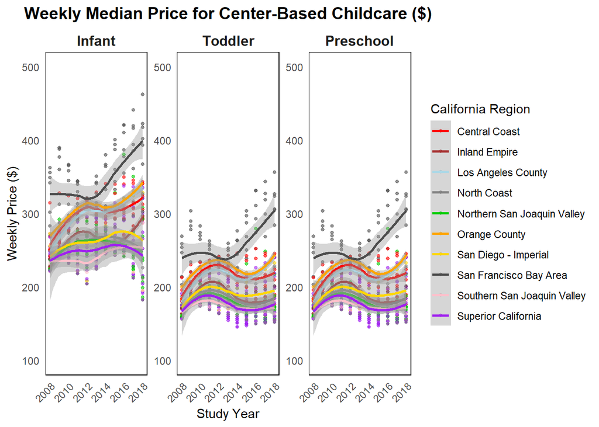

```r
library(ggplot2)
library(dplyr)
library(tidyr)
#| label: recreate-plot

ca_childcare_long <- ca_childcare %>%
  pivot_longer(
    cols = c(mc_infant, mc_toddler, mc_preschool),
    names_to = "Childcare_Type",
    values_to = "Weekly_Price"
  ) %>%
  mutate(
    Childcare_Type = factor(
      recode(
        Childcare_Type,
        "mc_infant" = "Infant",
        "mc_toddler" = "Toddler",
        "mc_preschool" = "Preschool"
      ),
      levels = c("Infant", "Toddler", "Preschool")
    )
  )

ggplot(ca_childcare_long, aes(x = study_year, y = Weekly_Price, color = census_region)) +
  geom_point(alpha = 0.6, size = 1) +
  geom_smooth(method = "loess", se = TRUE, size = 1) +
  facet_wrap(~Childcare_Type, scales = "free_y", nrow = 1) +
  labs(
    title = "Weekly Median Price for Center-Based Childcare ($)",
    x = "Study Year",
    y = "Weekly Price ($)",
    color = "California Region"
  ) +
  theme_minimal() +
  theme(
    strip.text = element_text(face = "bold", size = 12),
    axis.text.x = element_text(angle = 45, hjust = 1),
    legend.position = "right",
    panel.grid = element_blank(),
    panel.border = element_rect(color = "black", fill = NA),
    plot.title = element_text(face = "bold", size = 14, hjust = 0.5)
  ) +
  scale_y_continuous(limits = c(100, 500), breaks = seq(100, 500, 100)) +
  scale_x_continuous(breaks = seq(2008, 2018, 2)) +
  scale_color_manual(
    values = c(
      "San Francisco Bay Area" = "grey30",
      "Orange County" = "orange",
      "Los Angeles County" = "lightblue",
      "Northern San Joaquin Valley" = "green3",
      "Central Coast" = "red",
      "Inland Empire" = "brown",
      "Superior California" = "purple",
      "Southern San Joaquin Valley" = "pink",
      "San Diego - Imperial" = "gold",
      "North Coast" = "grey50"
    )
  )
```

[output not shown]

## Median Household Income vs. Childcare Costs for Infants

**7. Create a scatterplot showing the relationship between median household income (expressed in 2018 dollars) and the full-time median weekly price charged for center-based childcare for an infant in California. Overlay a linear regression line (lm) to show the trend.**

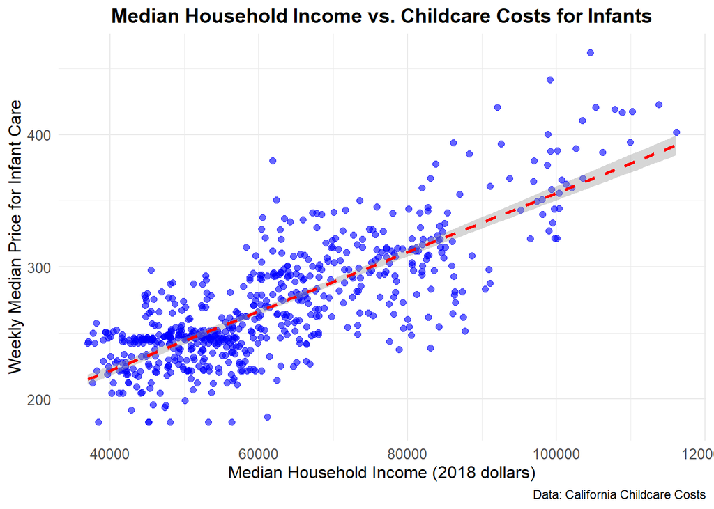

```r
library(ggplot2)
#| label: scatterplot-median-income-vs-childcare-cost

ggplot(ca_childcare, aes(x = mhi_2018, y = mc_infant)) +
  geom_point(alpha = 0.6, size = 2, color = "blue") +
  geom_smooth(method = "lm", se = TRUE, color = "red", linetype = "dashed") +
  labs(
    title = "Median Household Income vs. Childcare Costs for Infants",
    x = "Median Household Income (2018 dollars)",
    y = "Weekly Median Price for Infant Care",
    caption = "Data: California Childcare Costs"
  ) +
  theme_minimal() +
  theme(
    plot.title = element_text(face = "bold", size = 14, hjust = 0.5),
    axis.text = element_text(size = 10),
    axis.title = element_text(size = 12)
  )
```

**8. Look up the documentation for `lm()` and fit a linear regression model to the relationship shown in your plot above.**

```r
reg_mod1 <- lm(mc_infant ~ mhi_2018, data = ca_childcare)

summary(reg_mod1)
```

```
Call:
lm(formula = mc_infant ~ mhi_2018, data = ca_childcare)

Residuals:
    Min      1Q  Median      3Q     Max
-82.407 -15.606   0.097  15.999 110.026

Coefficients:
             Estimate Std. Error t value Pr(>|t|)
(Intercept) 1.317e+02  4.321e+00   30.49   <2e-16 ***
mhi_2018    2.241e-03  6.737e-05   33.26   <2e-16 ***
---
Signif. codes:  0 '***' 0.001 '**' 0.01 '*' 0.05 '.' 0.1 ' ' 1

Residual standard error: 27.48 on 636 degrees of freedom
Multiple R-squared:  0.635, Adjusted R-squared:  0.6344
F-statistic:  1106 on 1 and 636 DF,  p-value: < 2.2e-16
```

**9. Using the output from `summary()`, write out the estimated regression line (recall: $y = mx + b$).**

**10. Do you have evidence to conclude there is a relationship between the median household income and the median weekly cost of center-based childcare for infants in California? Cite values from your `summary()` output to support your claim!**

**There is strong evidence to conclude that there is a relationship between the median household income and the median weekly cost of the center-based childcare for infants in California.The slope (m = 0.002241) reveals that as the median household income increases, the childcare cost also increases. The p-value (< 2.2e-16) means there is a strong relationship between median household income and childcare cost. Lastly the R^2 value (63.5%) has a high value, which we can assume that median household income and childcare cost has a strong relationship.**